# 第14回 課題の答え合わせ

基本TODO①〜④と応用①②③

# 基本TODO

## TODO①：期待度数を自分で

```python
E2 = np.outer(ct.sum(axis=1), ct.sum(axis=0)) / ct.values.sum()
print(np.allclose(E, E2))
print(round(E2[ct.index.get_loc('Romance'), 0], 1))   # ロマンスの1930年代
```

```
True
20.7
```

- `ct.sum(axis=1)`が行（ジャンル）、`ct.sum(axis=0)`が列（年代）の合計

## TODO②：寄与率

```python
print(ca.eigenvalues_summary)
```

```
          eigenvalue % of variance % of variance (cumulative)
component
0              0.020        67.26%                     67.26%
1              0.005        16.64%                     83.90%
```

- 2本で83.9%

## TODO③：上位3ジャンル

```python
top3 = {}
for dec in ['1950', '1970']:
    top3[dec] = ratio[dec].sort_values(ascending=False).head(3).to_dict()
print(top3)
```

```
{'1950': {'Romance': 1.65, 'Sci-Fi': 1.47, 'Drama': 1.37}, '1970': {'Horror': 1.31, 'Sci-Fi': 1.23, 'Crime': 1.18}}
```

- 辞書の中に辞書。`top3['1950']['Romance']`で1.65が取り出せる

## TODO④：企画書の一文

```python
r = ratio['1960'].sort_values()
print(f'1960年代の特集は {r.index[-1]}（{r.iloc[-1]}倍）を中心に。'
      f'{r.index[0]}（{r.iloc[0]}倍）は少なめでよい。')
```

```
1960年代の特集は Adventure（1.38倍）を中心に。Thriller（0.69倍）は少なめでよい。
```

- 小さい順に並べると、最後がいちばん高い、最初がいちばん低い

# 課題

## 応用①：1990年代以降に絞る

```python
ct_new = ct[['1990', '2000', '2010']]         # 1990年代以降
ca_new = prince.CA(n_components=2, random_state=42).fit(ct_new)
rows_new = ca_new.row_coordinates(ct_new)
cols_new = ca_new.column_coordinates(ct_new)
print(ca_new.eigenvalues_summary)
fig, ax = plt.subplots(figsize=(8, 6))
draw_ca(ax, rows_new, cols_new)
plt.show()
```

[output not shown]

## 応用②：次元1の寄与率

```
答え: 88.8
```

- 正答は88.8。年代が3つだと、軸は2本で100%

## 2つの地図を並べる

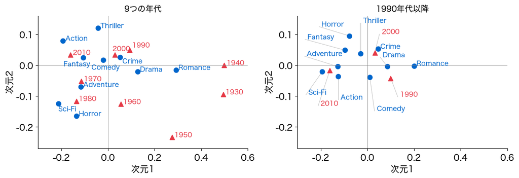

- 2枚の目盛りを、そろえて並べた

## 時代の軸は、残る

- 右に1990年代とロマンス・ドラマ
- 左に2010年代とSF・アクション・冒険もの

## ホラーが、動いた

- 9つの年代：SFのすぐ近く（1970・1980年代寄り）
- 1990年代以降：SFから離れ、ファンタジーの近く

## 古い端が抜けて、狭くなった

- 右の端にいた1930〜50年代が、なくなった
- 3つの年代のあいだにも、ジャンルの違いは残る（2010年代のSF・アクション）

## 応用③：模範例

1990年代以降に絞っても、右に1990年代とロマンス・ドラマ、左に2010年代とSF・アクション・冒険ものが並び、時代の軸は残りました。

いちばん変わったのはホラーで、SFのすぐ近くから離れ、ファンタジーの近くに移りました。

最近の3つの年代どうしでもジャンルの違いは残っているので、最近の年代の特集も、ジャンルで時代らしさを出せると思います。

## 書き方の型

- 1文目：残ったこと（時代の軸）
- 2文目：いちばん変わったこと（ホラー）
- 3文目：企画担当者への提案

# まとめ

## まとめと、発展動画へ

- 期待度数は`np.outer`、倍率は`ct / E`
- 絞ると、残るものと変わるものを比べる

発展動画：多重対応分析（MCA）。区分が3つ以上あるとき。